# **Projet final du Kit Big Data 2022**

Le projet final du Kit Big Data 2022 porte sur les données du Vendée Globe 2020-2021.

```python
import pandas as pd
import numpy as np
import io
from io import StringIO
import xlwings as xw
import requests
from bs4 import BeautifulSoup
import time
import datetime
import urllib
import os
```

```python
import matplotlib.pyplot as plt
import seaborn as sns
import pandas as pd
from sklearn import linear_model
from sklearn.linear_model import LogisticRegression
import plotly.express as px
import re
import cartopy as ctp
import cartopy.crs as ccrs
```

```python
from sklearn.model_selection import train_test_split
from sklearn.ensemble import RandomForestClassifier
from sklearn.neighbors import KNeighborsClassifier
from sklearn.metrics import classification_report
from sklearn.linear_model import LogisticRegression
```

```python
import random
from ipyleaflet import Map, basemaps, basemap_to_tiles, Marker, AntPath, CircleMarker, Popup, AwesomeIcon, projections, LayersControl, LayerGroup
from ipywidgets import HTML
```

**Partie 1 : Acquisition et chargement des données :**

- Acquérir l'ensemble des fichiers Excel des classements via la page de classement.
- Mettre en place une copie locale des fichiers Excel afin de ne pas les recharger à chaque run.
- Vers la fin de la course le format des fichiers Excel change avec les arrivées des voiliers : il est possible de s'arrêter juste avant.
- Acquérir les caractéristiques des bateaux.

**Partie 2 : Préparation des données :**

- Préparation des données relatives aux classements.
- Extraction des caractéristiques techniques de chacun des voiliers.
- Rapprochement des données des voiliers avec celle des classements.

### Récupération de l'ensemble des fichiers de classements et mettre en place une copie locale des fichiers Excel

Les classements sont des données sous format Excel disponible via l'adresse URL :https://www.vendeeglobe.org/fr/classement. Les classements sont publiés à 4h 8h 11h 14h 17h 21h (6 fois par jour)

La course a démarré le 8/11/2020 à 12h02.

Tout d'abord on commence par récupérer la liste des fichiers de classement

```python
url = 'https://www.vendeeglobe.org/fr/classement/20210305_080000'
page = requests.get(url).content
soup = BeautifulSoup(page)
pages_classements = []
for item in soup.find_all('option'):
    pages_classements.append(item.get('value'))
del pages_classements[0]

print("Il y a " + str(len(pages_classements)) + " pages de classement")
print("Premier classement :  " + str(pages_classements[705]))
print("Dernier classement :  " + str(pages_classements[0]))
```

```
Il y a 706 pages de classement
Premier classement :  20201108_120200
Dernier classement :  20210305_080000
```

Vers la fin de la course le format des fichiers Excel change avec les arrivées des voiliers donc on a choisi de s'arreter juste avant la date de l'arrivé du premier voilier qui est le 27/01/2021

```python
del pages_classements[705]
```

```python
index = pages_classements.index("20210127_140000")
pages_classement = pages_classements [index:]


print("On ne garde que les  " + str(len(pages_classement)) + " pages de classement enregistrées avant l'arrivé du premier voilier")
print("Premier classement :  " + str(pages_classement[484]))
print("Dernier classement :  " + str(pages_classement[0]))
```

```
On ne garde que les  485 pages de classement enregistrées avant l'arrivé du premier voilier
Premier classement :  20201108_140000
Dernier classement :  20210127_140000
```

```python
# Téléchargement des fichiers
for i in range(len(pages_classement)):
    path = 'https://www.vendeeglobe.org/download-race-data/vendeeglobe_{}.xlsx'
    idd = pages_classement[i]
    fichier_source = path.format(idd)
    fichier_cible = 'C:/Users/DELL/Desktop/classement/vendeeglobe_{}.xlsx'.format(idd)
    #urllib.request.urlretrieve(fichier_source, fichier_cible)

print('Téléchargement  terminé')
```

```
Téléchargement  terminé
```

## Préparation des données relatives aux classements

Dans cette partie nous avons définie une fonction qui permet d'afficher un fichier excel à partir d'une date tout en faisant un nettoyage de données comme ci dessous :

```python
name=['0','Rang','Id','Bateau','HR','Lat','Long','1','2','3','4','Cap','Vitesse','VMG','Distance','5','6','7','8','DTF','DTL']
```

```python
#date sous format : 'aaaammjj_hhmmss'
def get_bd (date) :

    url_base="C:/Users/DELL/Desktop/classement/vendeeglobe_"
    url = url_base+date+'.xlsx'
    with xw.Book(url, mode="r") as book:
                sheet1 = book.sheets[0]
                data = sheet1.cells.value
    df1 = pd.DataFrame(data)

    dfs= pd.read_csv(io.StringIO(u""+df1.to_csv(header=None)), header=None,skiprows=5,names=name,nrows=33,encoding='UTF-8')

    dfs["Skipper"] = dfs["Bateau"].apply(lambda x: str(x.split('\n')[0].upper())).astype(str)
    dfs["Skipper"] = dfs["Skipper"].apply(lambda x : str(x).split("\r")[0])
    dfs["Skipper"] = dfs["Skipper"].apply(lambda x : x.title())
    #dfs["Bateau"] = dfs["Bateau"].apply(lambda x: str(x.split('\n')[1].upper())).astype(str)
    #dfs["Nat"]= dfs["Id"].apply(lambda x: str(x.split('\n')[1].upper())).apply(lambda x: str(x.split(' ')[0].upper())).astype(str)
    #dfs["Id"]= dfs["Id"].apply(lambda x: str(x.split('\n')[1].upper())).apply(lambda x: str(x.split(' ')[1])).astype(int)
    date_time = datetime.datetime.strptime(str(url[-20:-5]), '%Y%m%d_%H%M%S').strftime('%Y/%m/%d %H:%M:%S')
    dfs["Update Time"] = date_time
    dfs =  dfs[~dfs.Rang.isin(["RET","NL"])]
    dfs["Rang"] = dfs["Rang"].apply(lambda x : int(x))
    for label in ["Vitesse", "VMG","Distance","DTF","DTL"]:
        dfs[label] = dfs[label].apply(lambda x : float(x.split(' ')[0]))
    dfs=dfs.reset_index(drop=True)
    dfs = dfs.drop(['0','1','2','3','4','5','6','7','8','HR','Bateau','Id'],axis=1)
    return dfs[['Rang', 'Skipper','Lat','Long','Cap','Vitesse','VMG','Distance','DTF','DTL','Update Time']]
```

```python
get_bd('20201110_140000')
```

|  | Rang | Skipper | Lat | Long | Cap | Vitesse | VMG | Distance | DTF | DTL | Update Time |
| --- | --- | --- | --- | --- | --- | --- | --- | --- | --- | --- | --- |
| 0 | 1 | Benjamin Dutreux | 42°25.35'N | 10°14.38'W | 225° | 11.5 | 10.6 | 34.6 | 23866.3 | 0.0 | 2020/11/10 14:00:00 |
| 1 | 2 | Maxime Sorel | 42°24.27'N | 10°06.26'W | 216° | 11.4 | 11.0 | 34.1 | 23867.5 | 1.2 | 2020/11/10 14:00:00 |
| 2 | 3 | Jean Le Cam | 42°32.68'N | 10°23.08'W | 241° | 11.5 | 9.0 | 34.6 | 23870.8 | 4.5 | 2020/11/10 14:00:00 |
| 3 | 4 | Nicolas Troussel | 42°35.45'N | 10°25.33'W | 241° | 11.9 | 9.2 | 35.6 | 23872.8 | 6.5 | 2020/11/10 14:00:00 |
| 4 | 5 | Damien Seguin | 42°40.06'N | 10°32.03'W | 258° | 12.7 | 7.2 | 38.1 | 23875.3 | 9.1 | 2020/11/10 14:00:00 |
| 5 | 6 | Romain Attanasio | 42°35.77'N | 10°13.06'W | 233° | 11.7 | 10.1 | 35.2 | 23876.4 | 10.1 | 2020/11/10 14:00:00 |
| 6 | 7 | Jérémie Beyou | 43°24.57'N | 12°22.09'W | 270° | 16.8 | 5.5 | 50.4 | 23890.5 | 24.2 | 2020/11/10 14:00:00 |
| 7 | 8 | Charlie Dalin | 43°33.78'N | 12°35.78'W | 264° | 17.4 | 7.4 | 52.3 | 23896.3 | 30.0 | 2020/11/10 14:00:00 |
| 8 | 9 | Kevin Escoffier | 43°28.93'N | 12°12.75'W | 265° | 16.1 | 6.7 | 48.2 | 23896.8 | 30.5 | 2020/11/10 14:00:00 |
| 9 | 10 | Yannick Bestaven | 42°54.90'N | 09°41.79'W | 222° | 9.6 | 9.1 | 28.9 | 23902.6 | 36.3 | 2020/11/10 14:00:00 |
| 10 | 11 | Stéphane Le Diraison | 42°53.69'N | 09°37.35'W | 227° | 9.0 | 8.2 | 27.0 | 23902.7 | 36.4 | 2020/11/10 14:00:00 |
| 11 | 12 | Samantha Davies | 43°31.06'N | 11°40.74'W | 265° | 13.1 | 5.5 | 39.3 | 23906.2 | 39.9 | 2020/11/10 14:00:00 |
| 12 | 13 | Didac Costa | 43°01.39'N | 09°39.00'W | 228° | 8.4 | 7.6 | 25.3 | 23909.4 | 43.1 | 2020/11/10 14:00:00 |
| 13 | 14 | Manuel Cousin | 43°04.28'N | 09°26.02'W | 193° | 6.5 | 6.4 | 19.5 | 23915.6 | 49.4 | 2020/11/10 14:00:00 |
| 14 | 15 | Sébastien Simon | 44°00.33'N | 12°49.96'W | 253° | 15.1 | 8.8 | 45.3 | 23918.5 | 52.2 | 2020/11/10 14:00:00 |
| 15 | 16 | Isabelle Joschke | 43°36.23'N | 10°43.43'W | 216° | 6.2 | 5.9 | 18.5 | 23925.1 | 58.8 | 2020/11/10 14:00:00 |
| 16 | 17 | Alex Thomson | 44°09.93'N | 12°39.44'W | 268° | 16.1 | 5.6 | 48.3 | 23929.9 | 63.7 | 2020/11/10 14:00:00 |
| 17 | 18 | Clarisse Cremer | 44°02.21'N | 12°04.97'W | 247° | 11.2 | 7.6 | 33.6 | 23930.2 | 63.9 | 2020/11/10 14:00:00 |
| 18 | 19 | Boris Herrmann | 44°12.58'N | 12°42.11'W | 265° | 14.7 | 5.9 | 44.2 | 23931.9 | 65.6 | 2020/11/10 14:00:00 |
| 19 | 20 | Clément Giraud | 43°32.99'N | 09°58.83'W | 256° | 11.0 | 6.5 | 32.9 | 23933.5 | 67.2 | 2020/11/10 14:00:00 |
| 20 | 21 | Armel Tripon | 44°26.24'N | 13°30.62'W | 257° | 13.4 | 6.8 | 40.2 | 23935.0 | 68.7 | 2020/11/10 14:00:00 |
| 21 | 22 | Ari Huusela | 43°34.51'N | 09°53.11'W | 257° | 11.1 | 6.5 | 33.3 | 23936.4 | 70.1 | 2020/11/10 14:00:00 |
| 22 | 23 | Thomas Ruyant | 44°31.24'N | 13°37.35'W | 247° | 13.4 | 8.6 | 40.3 | 23938.4 | 72.1 | 2020/11/10 14:00:00 |
| 23 | 24 | Alan Roura | 43°58.00'N | 11°02.62'W | 255° | 10.9 | 6.4 | 32.7 | 23940.8 | 74.5 | 2020/11/10 14:00:00 |
| 24 | 25 | Miranda Merron | 43°55.99'N | 10°29.53'W | 263° | 9.4 | 4.5 | 28.2 | 23947.1 | 80.8 | 2020/11/10 14:00:00 |
| 25 | 26 | Pip Hare | 43°54.69'N | 10°12.92'W | 273° | 10.3 | 3.3 | 30.8 | 23950.1 | 83.8 | 2020/11/10 14:00:00 |
| 26 | 27 | Louis Burton | 44°42.25'N | 13°30.72'W | 257° | 13.2 | 6.7 | 39.5 | 23950.3 | 84.0 | 2020/11/10 14:00:00 |
| 27 | 28 | Giancarlo Pedote | 44°31.37'N | 12°16.58'W | 249° | 10.9 | 6.9 | 32.7 | 23955.3 | 89.1 | 2020/11/10 14:00:00 |
| 28 | 29 | Arnaud Boissieres | 43°51.49'N | 09°03.16'W | 235° | 7.5 | 6.3 | 22.5 | 23965.6 | 99.4 | 2020/11/10 14:00:00 |
| 29 | 30 | Kojiro Shiraishi | 44°41.35'N | 11°33.56'W | 262° | 12.5 | 5.9 | 37.6 | 23974.5 | 108.2 | 2020/11/10 14:00:00 |
| 30 | 31 | Alexia Barrier | 44°31.29'N | 10°28.79'W | 258° | 9.7 | 5.3 | 29.0 | 23980.4 | 114.1 | 2020/11/10 14:00:00 |
| 31 | 32 | Sébastien Destremau | 44°27.43'N | 10°05.85'W | 246° | 8.2 | 5.9 | 24.7 | 23982.5 | 116.2 | 2020/11/10 14:00:00 |
| 32 | 33 | Fabrice Amedeo | 46°30.13'N | 01°47.42'W | 187° | 0.0 | 0.0 | 0.0 | 24298.4 | 432.1 | 2020/11/10 14:00:00 |

```python
get_bd('20201110_140000').info()
```

```
<class 'pandas.core.frame.DataFrame'>
RangeIndex: 33 entries, 0 to 32
Data columns (total 11 columns):
 #   Column       Non-Null Count  Dtype
---  ------       --------------  -----
 0   Rang         33 non-null     int64
 1   Skipper      33 non-null     object
 2   Lat          33 non-null     object
 3   Long         33 non-null     object
 4   Cap          33 non-null     object
 5   Vitesse      33 non-null     float64
 6   VMG          33 non-null     float64
 7   Distance     33 non-null     float64
 8   DTF          33 non-null     float64
 9   DTL          33 non-null     float64
 10  Update Time  33 non-null     object
dtypes: float64(5), int64(1), object(5)
memory usage: 3.0+ KB
```

```python
def concat_all():
    """Retourne une concaténation des classements """
    classements_listes = []
    for cls in pages_classement:
        classements_listes.append(get_bd(cls))
    df = pd.concat(classements_listes)
    df.to_csv('C:/Users/DELL/Desktop/all_rankings.csv')
    return df
```

```python
concat_all()
```

|  | Rang | Skipper | Lat | Long | Cap | Vitesse | VMG | Distance | DTF | DTL | Update Time |
| --- | --- | --- | --- | --- | --- | --- | --- | --- | --- | --- | --- |
| 0 | 1 | Charlie Dalin | 46°14.07'N | 03°41.61'W | 37° | 19.1 | 17.4 | 57.2 | 80.5 | 0.0 | 2021/01/27 14:00:00 |
| 1 | 2 | Louis Burton | 46°24.62'N | 05°11.90'W | 110° | 17.7 | 16.9 | 53.3 | 141.5 | 60.9 | 2021/01/27 14:00:00 |
| 2 | 3 | Boris Herrmann | 44°31.46'N | 05°20.55'W | 113° | 16.6 | 10.3 | 49.9 | 190.0 | 109.5 | 2021/01/27 14:00:00 |
| 3 | 4 | Thomas Ruyant | 47°24.42'N | 07°22.08'W | 102° | 17.6 | 17.6 | 52.9 | 235.8 | 155.3 | 2021/01/27 14:00:00 |
| 4 | 5 | Yannick Bestaven | 47°43.38'N | 07°58.81'W | 98° | 18.1 | 18.1 | 54.4 | 264.3 | 183.7 | 2021/01/27 14:00:00 |
| ... | ... | ... | ... | ... | ... | ... | ... | ... | ... | ... | ... |
| 26 | 27 | Alexia Barrier | 46°25.83'N | 01°48.92'W | 357° | 0.0 | 0.0 | 2789.4 | 24295.4 | 1.6 | 2020/11/08 14:00:00 |
| 27 | 28 | Isabelle Joschke | 46°24.98'N | 01°48.22'W | 358° | 0.0 | 0.0 | 2788.5 | 24295.5 | 1.6 | 2020/11/08 14:00:00 |
| 28 | 29 | Sébastien Simon | 46°25.75'N | 01°48.73'W | 357° | 0.0 | 0.0 | 2789.3 | 24295.5 | 1.6 | 2020/11/08 14:00:00 |
| 29 | 30 | Miranda Merron | 46°25.39'N | 01°48.34'W | 358° | 0.0 | 0.0 | 2788.9 | 24295.6 | 1.7 | 2020/11/08 14:00:00 |
| 30 | 31 | Ari Huusela | 46°25.65'N | 01°48.21'W | 358° | 0.0 | 0.0 | 2789.1 | 24295.8 | 1.9 | 2020/11/08 14:00:00 |

13784 rows × 11 columns

### Acquérir les caractéristiques des bateaux

```python
def get_bateau_infos() :
    url = 'https://www.vendeeglobe.org/fr/glossaire'
    req = requests.get(url)
    soup = BeautifulSoup(req.content.decode('utf-8'))
    bateaux = []
    for elt in soup.find('section', {"class": "boats-list"}).find_all("div", {"class" : "boats-list__popup-infos"}) :
        bateau = {}
        bateau["Nom bateau"] = elt.find("h3", {"class": "boats-list__popup-title" }).text
        for i in elt.find_all('li') :
            key = i.text.split(' : ')[0]
            value = i.text.split(' : ')[1]
            bateau[key] = value
        bateaux.append(bateau)
    skippers = [ x.text for x in soup.find_all("span", {"class" : "boats-list__skipper-name"}, text= True)]
    for i in range(len(skippers)):
        bateaux[i]["Skipper"] = skippers.pop(0)
    df = pd.DataFrame(bateaux)
    df = df.replace('Sam Davies', 'Samantha Davies')
    df = df.replace('foiler','foils')
    df['Foils'] = df['Nombre de dérives'].str.contains('foil')
    df["Longueur"] = 18.28
    df["Tirant d'eau"] = 4.5
    df["Skipper"] = df["Skipper"].apply(lambda x : x.title())
    for label in ["Hauteur mât","Largeur"]:
        df[label] = df[label].str.replace('m',' ')
        df[label] = df[label].str.replace(',','.').apply(lambda x : float(x))
    for label in ["Surface de voiles au près","Surface de voiles au portant"]:
        df[label] = df[label].str.replace('m²',' ')
        df[label] = df[label].str.replace('m2',' ')
        df[label] = df[label].str.replace(',','.').apply(lambda x : float(x))
    label = "Déplacement (poids)"
    df[label] = df[label].str.replace('tonnes','t')
    df[label] = df[label].str.replace('NC','8')
    df[label] = df[label].str.replace('nc','8')
    df[label] = df[label].str.replace('t',' ')
    df[label] = df[label].str.replace(',','.').apply(lambda x : float(x))
    df.to_csv("C:/Users/DELL/Desktop/Bateaux/bateaux_info.csv")
    return df
```

```python
get_bateau_infos()
```

|  | Nom bateau | Numéro de voile | Anciens noms du bateau | Architecte | Chantier | Date de lancement | Longueur | Largeur | Tirant d'eau | Déplacement (poids) | Nombre de dérives | Hauteur mât | Voile quille | Surface de voiles au près | Surface de voiles au portant | Skipper | Foils |
| --- | --- | --- | --- | --- | --- | --- | --- | --- | --- | --- | --- | --- | --- | --- | --- | --- | --- |
| 0 | NEWREST - ART & FENÊTRES | FRA 56 | No Way Back, Vento di Sardegna | VPLP/Verdier | Persico Marine | 01 Août 2015 | 18.28 | 5.85 | 4.5 | 7.0 | foils | 29.0 | monotype | 320.0 | 570.0 | Fabrice Amedeo | True |
| 1 | PURE - Best Western® | FRA 49 | Gitana Eighty, Synerciel, Newrest-Matmut | Bruce Farr Design | Southern Ocean Marine (Nouvelle Zélande) | 08 Mars 2007 | 18.28 | 5.80 | 4.5 | 9.0 | 2 | 28.0 | acier forgé | 280.0 | 560.0 | Romain Attanasio | False |
| 2 | TSE - 4MYPLANET | FRA72 | Famille Mary-Etamine du Lys, Initiatives Coeur... | Marc Lombard | MAG France | 01 Mars 1998 | 18.28 | 5.54 | 4.5 | 9.0 | 2 | 29.0 | acier | 260.0 | 580.0 | Alexia Barrier | False |
| 3 | Maître CoQ IV | 17 | Safran 2 - Des Voiles et Vous | Verdier - VPLP | CDK Technologies | 12 Mars 2015 | 18.28 | 5.80 | 4.5 | 8.0 | foils | 29.0 | acier mécano soudé | 310.0 | 550.0 | Yannick Bestaven | True |
| 4 | CHARAL | 08 | NaN | VPLP | CDK Technologies | 18 Août 2018 | 18.28 | 5.85 | 4.5 | 8.0 | foils | 29.0 | acier | 320.0 | 600.0 | Jérémie Beyou | True |
| 5 | LA MIE CÂLINE - ARTISANS ARTIPÔLE | FRA 14 | Ecover3, Président, Gamesa, Kilcullen Voyager-... | Owen Clarke Design LLP - Clay Oliver | Hakes Marine - Mer Agitée | 03 Août 2007 | 18.28 | 5.65 | 4.5 | 7.9 | foils | 29.0 | basculante avec vérin | 300.0 | 610.0 | Arnaud Boissières | True |
| 6 | BUREAU VALLEE 2 | 18 | Banque Populaire VIII | Verdier - VPLP | CDK Technologies | 09 Juin 2015 | 18.28 | 5.80 | 4.5 | 7.6 | foils | 28.0 | acier | 300.0 | 600.0 | Louis Burton | True |
| 7 | ONE PLANET ONE OCEAN | ESP 33 | Kingfisher - Educacion sin Fronteras - Forum M... | Owen Clarke Design | Martens Yachts | 02 Février 2000 | 18.28 | 5.30 | 4.5 | 8.9 | 2 | 26.0 | acier | 240.0 | 470.0 | Didac Costa | False |
| 8 | GROUPE SÉTIN | FRA 71 | Paprec-Virbac2, Estrella Damm, We are Water, L... | Bruce Farr Yacht Design | Southern Ocean Marine (Nouvelle-Zélande) | 02 Février 2007 | 18.28 | 5.80 | 4.5 | 9.0 | 2 asymétriques | 28.5 | basculante sur vérin hydraulique | 270.0 | 560.0 | Manuel Cousin | False |
| 9 | BANQUE POPULAIRE X | FRA30 | Macif - SMA | Verdier - VPLP | CDK - Mer Agitée | 01 Mars 2011 | 18.28 | 5.70 | 4.5 | 7.7 | 2 | 29.0 | acier forgé | 340.0 | 570.0 | Clarisse Cremer | False |
| 10 | APIVIA | FRA 79 | NaN | Verdier | CDK technologies - MerConcept | 05 Août 2019 | 18.28 | 5.85 | 4.5 | 8.0 | foils | 29.0 | acier | 350.0 | 560.0 | Charlie Dalin | True |
| 11 | INITIATIVES-COEUR | FRA109 | Maître CoQ - Banque Populaire VII- Foncia II | VPLP - Verdier | CDK Technologies | 20 Septembre 2010 | 18.28 | 5.70 | 4.5 | 7.8 | foils | 27.0 | acier forgé | 300.0 | 600.0 | Sam Davies | True |
| 12 | MERCI | 69 | Foresight Natural Energy, Maisonneuve | Lavanos | Artech do Brasil | 15 Janvier 2005 | 18.28 | 5.60 | 4.5 | 8.5 | 2 | 29.0 | acier | 250.0 | 650.0 | Sébastien Destremau | False |
| 13 | OMIA - WATER FAMILY | FRA09 | Spirit of Yukoh, Neutrogena, Hugo Boss, Estrel... | Bruce Farr Design | Offshore Challenge - Cowes | 03 Juillet 2007 | 18.28 | 5.85 | 4.5 | 8.0 | 2 | 29.0 | acier forgé | 300.0 | 700.0 | Benjamin Dutreux | False |
| 14 | PRB | FRA 85 | NaN | Verdier - VPLP | CDK Technologies | 08 Mars 2010 | 18.28 | 5.50 | 4.5 | 8.0 | foils | 27.4 | Acier mécano soudé | 300.0 | 600.0 | Kevin Escoffier | True |
| 15 | Compagnie du Lit / Jiliti | FRA83 | Delta Dore, Bureau Vallée, Vers un Monde sans ... | Bruce Farr design | JMV Cherbourg | 26 Juillet 2006 | 18.28 | 5.75 | 4.5 | 8.5 | 2 | 29.0 | acier forgé | 300.0 | 620.0 | Clément Giraud | False |
| 16 |  | NaN | NaN | NaN | NaN | 01 Janvier 1970 | 18.28 | NaN | 4.5 | NaN | NaN | NaN | NaN | NaN | NaN | François Guiffant | NaN |
| 17 | MEDALLIA | GBR77 | Armor Lux, We Are Water, La Fabrique | Pierre Rolland | Bernard Stamm | 03 Juillet 1999 | 18.28 | 5.70 | 4.5 | 9.0 | 2 | 29.0 | carbone | 300.0 | 580.0 | Pip Hare | False |
| 18 | SEAEXPLORER - YACHT CLUB DE MONACO | 16 | Edmond de Rothschild, Malizia - Yacht Club de ... | Verdier - VPLP | Multiplast | 07 Août 2015 | 18.28 | 5.70 | 4.5 | 7.6 | foils | 29.0 | acier | 290.0 | 490.0 | Boris Herrmann | True |
| 19 | STARK | FIN222 | Aviva, GAES Centros Auditivos | Owen Clarke Design | Hakes Marine - Wellington (Nouvelle-Zélande) | 06 Août 2007 | 18.28 | 5.80 | 4.5 | 8.5 | 2 | 28.0 | acier | 270.0 | 580.0 | Ari Huusela | False |
| 20 | MACSF | FRA 27 | Quéguiner, Safran | Verdier - VPLP | Chantier Naval de Larros | 04 Juillet 2007 | 18.28 | 5.60 | 4.5 | 7.7 | foils | 27.0 | acier | 300.0 | 650.0 | Isabelle Joschke | True |
| 21 | Yes We Cam! | 001 | Cheminées Poujoulat, Mare, Maître CoQ, Mapfre,... | Bruce Farr design | CDK Technologies | 03 Janvier 2007 | 18.28 | 5.90 | 4.5 | 8.0 | 2 | 28.0 | acier forgé | 300.0 | 620.0 | Jean Le Cam | False |
| 22 | TIME FOR OCEANS | FRA 92 | Hugo Boss, Energa, Compagnie du Lit-Boulogne B... | Finot-Conq Design | Neville Hutton | 01 Juin 2007 | 18.28 | 5.84 | 4.5 | 8.5 | foils | 28.0 | monotype | 300.0 | 550.0 | Stéphane Le Diraison | True |
| 23 | CAMPAGNE DE FRANCE | FRA50 | Great America IV, Mirabaud, Temenos | Owen Clarke | Southern Ocean Marine, Tauranga | 04 Mai 2006 | 18.28 | 5.50 | 4.5 | 8.5 | 2 | 28.0 | carbone | 330.0 | 600.0 | Miranda Merron | False |
| 24 | PRYSMIAN GROUP | ITA 34 | Saint-Michel - Virbac | VPLP - Verdier | Multiplast | 02 Avril 2015 | 18.28 | 5.80 | 4.5 | 8.0 | foils | 29.0 | acier forgé | 300.0 | 600.0 | Giancarlo Pedote | True |
| 25 | LA FABRIQUE | SUI07 | Brit Air, Votre Nom autour du Monde, MACSF | Groupe Finot-Conq | Multiplast | 01 Août 2007 | 18.28 | 5.90 | 4.5 | 8.0 | foils | 27.0 | carbone | 290.0 | 580.0 | Alan Roura | True |
| 26 | LinkedOut | NaN | NaN | Verdier | Persico | 03 Septembre 2019 | 18.28 | 5.85 | 4.5 | 8.0 | foils | 29.0 | acier forgé | 350.0 | 560.0 | Thomas Ruyant | True |
| 27 | GROUPE APICIL | FRA1000 | Comme Un Seul Homme, DCNS | Groupe Finot-Conq | Multiplast | 10 Août 2008 | 18.28 | 5.85 | 4.5 | 8.5 | 2 | 29.0 | acier forgé | 350.0 | 610.0 | Damien Seguin | False |
| 28 | DMG MORI Global One | JPN 11 | NaN | VPLP | Multiplast | 05 Septembre 2019 | 18.28 | 5.85 | 4.5 | 8.0 | foils | 29.0 | acier forgé | 320.0 | 580.0 | Kojiro Shiraishi | True |
| 29 | ARKEA PAPREC | 4 | NaN | Juan Kouyoumdjian | CDK Technologies / Assemblage | 19 Juillet 2019 | 18.28 | 5.70 | 4.5 | 8.0 | foils | 29.0 | Inox usiné | 260.0 | 600.0 | Sébastien Simon | True |
| 30 | V and B-MAYENNE | FRA53 | Le Souffle du Nord, Groupe Bel | Verdier - VPLP | Indiana Yachting (Scarlino, Italie) | 07 Septembre 2007 | 18.28 | 5.50 | 4.5 | 7.7 | 2 | 29.0 | acier | 365.0 | 700.0 | Maxime Sorel | False |
| 31 | HUGO BOSS | GBR 99 | NaN | VPLP - Alex Thomson Racing (led by Pete Hobson) | Carrington Boats | 15 Août 2019 | 18.28 | 5.40 | 4.5 | 7.7 | foils | 29.0 | acier forgé | 330.0 | 630.0 | Alex Thomson | True |
| 32 | L'OCCITANE EN PROVENCE | 2 | NaN | Samuel Manuard | Black Pepper© | 31 Janvier 2020 | 18.28 | 5.50 | 4.5 | 7.8 | foils | 28.0 | acier forgé | 270.0 | 535.0 | Armel Tripon | True |
| 33 | CORUM L'EPARGNE | FRA 6 | NaN | Juan Kouyoumdjian | CDK technologies - Mer Agitée | 15 Mai 2020 | 18.28 | 5.70 | 4.5 | 7.9 | foils | 27.3 | NaN | 270.0 | 535.0 | Nicolas Troussel | True |

## Rapprochement des données des voiliers avec celle des classements.

```python
# Utilisation de la variable Skipper pour faire la jointure et conservation de l'index du classement
def merge_classement_bateau():
    df_bateaux = pd.read_csv("C:/Users/DELL/Desktop/bateaux/bateaux_info.csv",index_col=[0])
    df_classement = pd.read_csv("C:/Users/DELL/Desktop/all_rankings.csv", index_col=[0])
    df_All = df_classement.merge(df_bateaux, on ="Skipper")
    return df_All
```

```python
merge_classement_bateau()
```

|  | Rang | Skipper | Lat | Long | Cap | Vitesse | VMG | Distance | DTF | DTL | ... | Longueur | Largeur | Tirant d'eau | Déplacement (poids) | Nombre de dérives | Hauteur mât | Voile quille | Surface de voiles au près | Surface de voiles au portant | Foils |
| --- | --- | --- | --- | --- | --- | --- | --- | --- | --- | --- | --- | --- | --- | --- | --- | --- | --- | --- | --- | --- | --- |
| 0 | 1 | Charlie Dalin | 46°14.07'N | 03°41.61'W | 37° | 19.1 | 17.4 | 57.2 | 80.5 | 0.0 | ... | 18.28 | 5.85 | 4.5 | 8.0 | foils | 29.0 | acier | 350.0 | 560.0 | True |
| 1 | 1 | Charlie Dalin | 45°28.35'N | 04°30.86'W | 42° | 19.4 | 19.0 | 58.3 | 128.9 | 0.0 | ... | 18.28 | 5.85 | 4.5 | 8.0 | foils | 29.0 | acier | 350.0 | 560.0 | True |
| 2 | 1 | Charlie Dalin | 44°44.72'N | 05°25.61'W | 48° | 19.1 | 19.1 | 76.5 | 184.9 | 0.0 | ... | 18.28 | 5.85 | 4.5 | 8.0 | foils | 29.0 | acier | 350.0 | 560.0 | True |
| 3 | 1 | Charlie Dalin | 43°53.46'N | 06°44.90'W | 93° | 13.4 | 11.4 | 94.0 | 261.0 | 0.0 | ... | 18.28 | 5.85 | 4.5 | 8.0 | foils | 29.0 | acier | 350.0 | 560.0 | True |
| 4 | 1 | Charlie Dalin | 43°56.62'N | 08°55.23'W | 58° | 11.2 | 11.2 | 44.8 | 337.8 | 0.0 | ... | 18.28 | 5.85 | 4.5 | 8.0 | foils | 29.0 | acier | 350.0 | 560.0 | True |
| ... | ... | ... | ... | ... | ... | ... | ... | ... | ... | ... | ... | ... | ... | ... | ... | ... | ... | ... | ... | ... | ... |
| 12649 | 5 | Nicolas Troussel | 46°30.70'N | 07°33.22'W | 278° | 14.7 | 4.7 | 103.0 | 24137.1 | 4.0 | ... | 18.28 | 5.70 | 4.5 | 7.9 | foils | 27.3 | NaN | 270.0 | 535.0 | True |
| 12650 | 2 | Nicolas Troussel | 46°14.80'N | 05°05.76'W | 263° | 17.9 | 15.7 | 71.8 | 24179.5 | 0.7 | ... | 18.28 | 5.70 | 4.5 | 7.9 | foils | 27.3 | NaN | 270.0 | 535.0 | True |
| 12651 | 6 | Nicolas Troussel | 46°22.46'N | 03°22.50'W | 271° | 22.9 | 19.4 | 34.3 | 24239.0 | 4.1 | ... | 18.28 | 5.70 | 4.5 | 7.9 | foils | 27.3 | NaN | 270.0 | 535.0 | True |
| 12652 | 6 | Nicolas Troussel | 46°21.97'N | 02°32.77'W | 262° | 19.6 | 18.2 | 30.3 | 24267.4 | 2.3 | ... | 18.28 | 5.70 | 4.5 | 7.9 | foils | 27.3 | NaN | 270.0 | 535.0 | True |
| 12653 | 20 | Nicolas Troussel | 46°25.80'N | 01°49.19'W | 357° | 0.0 | 0.0 | 2789.3 | 24295.2 | 1.4 | ... | 18.28 | 5.70 | 4.5 | 7.9 | foils | 27.3 | NaN | 270.0 | 535.0 | True |

12654 rows × 27 columns

**Partie 3 : Analyses et story telling :**

- Corrélation et régression linéaire entre le classement (rang) et la vitesse utile (VMG) des voiliers.
- Impact de la présence d'un foil sur le classement et la vitesse des voiliers.
- Visualisation de la distance parcourue par voilier.
- Cartes avec les routes d'un ou plusieurs voiliers.
- Analyses de séries temporelles.
- Application d'algorithmes statistiques ou de machine learning.

Corrélation et régression linéaire entre le classement (rang) et la vitesse utile (VMG) des voiliers.

```python
df1 = pd.read_csv('all_rankings.csv')
x1 = df1["Rang"]
x2 = df1["VMG"]
```

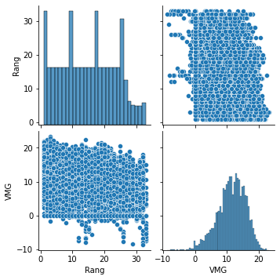

```python
sns.pairplot(df1[["Rang","VMG"]]);
```

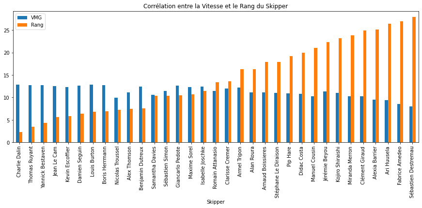

```python
plt.figure()
fig, ax = plt.subplots(1, 1, figsize=(15, 5))
plot = df1[['VMG', 'Rang', 'Skipper']].groupby('Skipper'). \
       mean(['VMG', 'Rang']).sort_values('Rang', ascending=True)
plot.plot.bar(ax = ax)
ax.set(xlabel = 'Skipper')
ax.set_title('Corrélation entre la Vitesse et le Rang du Skipper')
plt.show()
```

```python
linmod = linear_model.LinearRegression()
df_tmp = df1[['Rang', 'VMG']].groupby(by='Rang').mean().reset_index()
df_tmp1 = df1[['Rang', 'Vitesse']].groupby(by='Rang').mean().reset_index()


df_tmp = df_tmp[df_tmp['Rang'] < 33]
df_tmp1 = df_tmp1[df_tmp1['Rang'] < 33]


X = df_tmp[['VMG']]
Y = df_tmp['Rang']
linmod.fit(X, Y)



print('En utilisant ''sklearn.linear_model'', les paramètres estimés sont:')
print('b0 = {:.4f},'.format(linmod.intercept_))
print('b1 = {:.4f}.'.format(linmod.coef_[0]))

print('\nCoefficient de détermination R^2 = {:.4f}.'
      .format(linmod.score(X, Y)))
```

```
En utilisant sklearn.linear_model, les paramètres estimés sont:
b0 = 75.6429,
b1 = -5.3368.

Coefficient de détermination R^2 = 0.8861.
```

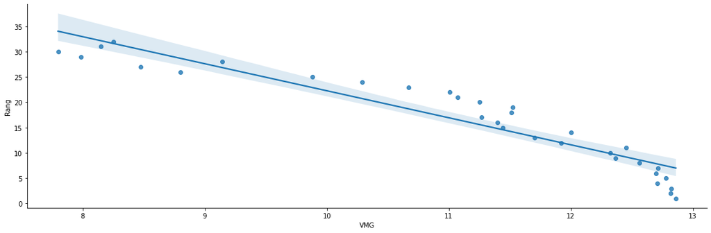

```python
sns.lmplot(x='VMG', y='Rang', data=df_tmp,
           height=5, aspect=3)
plt.show()
```

```python
linmod = linear_model.LinearRegression()
df_tmp1 = df1[['Rang', 'Vitesse']].groupby(by='Rang').mean().reset_index()

df_tmp1 = df_tmp1[df_tmp1['Rang'] < 33]

X = df_tmp1[['Vitesse']]
Y = df_tmp1['Rang']
linmod.fit(X, Y)



print('En utilisant ''sklearn.linear_model'', les paramètres estimés sont:')
print('b0 = {:.4f},'.format(linmod.intercept_))
print('b1 = {:.4f}.'.format(linmod.coef_[0]))

print('\nCoefficient de détermination R^2 = {:.4f}.'
      .format(linmod.score(X, Y)))
```

```
En utilisant sklearn.linear_model, les paramètres estimés sont:
b0 = 88.5160,
b1 = -5.7005.

Coefficient de détermination R^2 = 0.9067.
```

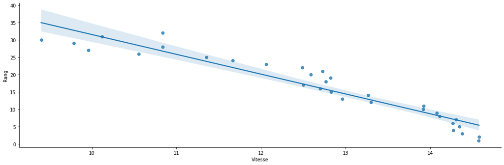

```python
sns.lmplot(x='Vitesse', y='Rang', data=df_tmp1,
           height=5, aspect=3)
plt.show()
```

### Impact de la présence d'un foil sur le classement et la vitesse des voiliers.

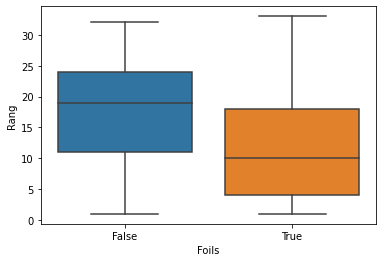

```python
df2 = pd.read_csv('merge_classement_bateaux.csv')
sns.boxplot(y = df2["Rang"], x = df2["Foils"]);
```

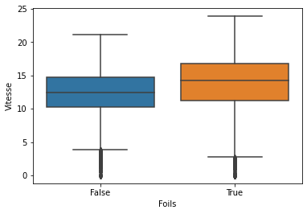

```python
sns.boxplot(y = df2["Vitesse"], x = df2["Foils"]);
```

On remarque les voiliers possédant un foil sont mieux classés et ont une meilleure vitesse dans la course.

## Distance parcourue par les voiliers

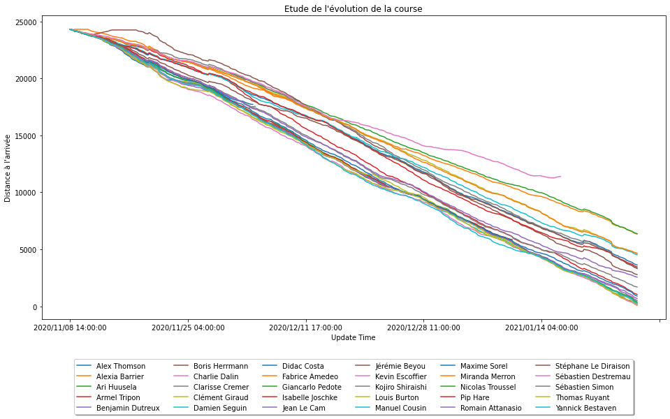

```python
pd.pivot_table(df2, values='DTF', index='Update Time', columns='Skipper').plot(figsize=[16,8])
plt.title("Etude de l'évolution de la course")
plt.ylabel("Distance à l'arrivée")
plt.legend(title=None, bbox_to_anchor=(0.5, -0.12), loc='upper center', ncol=6, fancybox=True, shadow=True)
plt.show()
```

## Visualisation de la route d'un voilier

```python
def dms_to_dec(position):
    temp = re.split("\W", position)
    pos = 1 if temp[3] in ["N", "E"] else -1
    return (float(temp[0]) + float(temp[1])/60 + float(temp[2])/3600) * pos

def get_parcours():
    df = pd.read_csv('merge_classement_bateaux.csv')
    df.dropna(inplace=True) # Suppression des données manquantes
    parcours = df.loc[:, ["Skipper", "Update Time"]]
    parcours["Lat"] = df["Lat"].apply(dms_to_dec)
    parcours["Long"] = df["Long"].apply(dms_to_dec)
    return parcours
```

```python
get_parcours()
```

|  | Skipper | Update Time | Lat | Long |
| --- | --- | --- | --- | --- |
| 484 | Louis Burton | 2021/01/27 14:00:00 | 46.417222 | -5.208333 |
| 485 | Louis Burton | 2021/01/27 11:00:00 | 46.711389 | -6.426944 |
| 486 | Louis Burton | 2021/01/27 08:00:00 | 46.845000 | -7.741389 |
| 487 | Louis Burton | 2021/01/27 04:00:00 | 46.938056 | -9.506667 |
| 488 | Louis Burton | 2021/01/26 21:00:00 | 47.282500 | -12.339722 |
| ... | ... | ... | ... | ... |
| 12148 | Fabrice Amedeo | 2020/11/09 04:00:00 | 46.492222 | -1.789167 |
| 12149 | Fabrice Amedeo | 2020/11/08 21:00:00 | 46.471944 | -2.505278 |
| 12150 | Fabrice Amedeo | 2020/11/08 17:00:00 | 46.404167 | -3.056944 |
| 12151 | Fabrice Amedeo | 2020/11/08 15:00:00 | 46.365833 | -2.434444 |
| 12152 | Fabrice Amedeo | 2020/11/08 14:00:00 | 46.421944 | -1.840833 |

9729 rows × 4 columns

```python
def add_course(m, skipper_name, parcours):
    col = "#%06x" % random.randint(0, 0xFFFFFF)
    course = parcours.groupby('Skipper').get_group(skipper_name).sort_values("Update Time")[["Lat", "Long"]].values.tolist()
    marker = CircleMarker(location=course[-1], color=col, radius=5)
    path = AntPath(locations=course, color=col)
    message = HTML(skipper_name)
    layer_group = LayerGroup(name=skipper_name, layers=(path, marker))
    m.add_layer(layer_group)
    marker.popup = message
```

Visualiser le parcours d'un seul skipper

```python
def parcours_skipper(skipper) :
 m = Map(
        basemap=basemap_to_tiles(basemaps.Esri.WorldImagery),
        center=(25, 2),
        zoom=2,
        close_popup_on_click=True
        )
 add_course(m,skipper,get_parcours())
 control = LayersControl(position='topright')
 m.add_control(control)
 return m
```

```python
parcours_skipper('Louis Burton')
```

[output not shown]

Visualiser le parcours de tout les skippers

```python
def generate_course_map(parcours):
    skipper_list = parcours["Skipper"].unique().tolist()
    m = Map(
        basemap=basemap_to_tiles(basemaps.Esri.WorldImagery),
        center=(25, 2),
        zoom=2,
        close_popup_on_click=True
        )
    for skipper in skipper_list:
        add_course(m, skipper, parcours)
    control = LayersControl(position='topright')
    m.add_control(control)
    return m
```

```python
generate_course_map(get_parcours())
```

[output not shown]